# NDFS Synthesis Manuscript: Chlorophyll analysis

Separate models using weekly average flow as continuous predictor

Dave Bosworth

October 26, 2026

# Purpose

Explore and analyze the continuous chlorophyll data to be included in the NDFS synthesis manuscript. We will attempt to fit multiple models to predict weekly average chlorophyll fluorescence values. All models will only include representative stations for 4 habitat types - upstream (RD22), lower Yolo Bypass (STTD), Cache Slough complex (LIB), and downstream (RVB). This notebook explores running the chlorophyll models for each of the 4 stations separately while using weekly average flow as a continuous predictor. Additionally, we’ll add a GAM smooth for Week number term to account for seasonality in all the models.

The zooplankton analysis used separate models for each station to allow for differing flow lag terms. We need to take a look at this approach to be consistent and see if it makes sense for the chlorophyll analysis. Since STTD, LIB and RVB are all downstream of LIS at different distances, the zooplankton analysis used lagged flow values as a predictor variable - using 1 week lag for STTD, a two week lag for LIB, and a 3 week lag for RVB. We’ll try something similar in this analysis.

# Global code and functions

```r
# Load packages
library(tidyverse)
library(scales)
library(knitr)
library(mgcv)
library(car)
library(gratia)
library(ggeffects)
library(emmeans)
library(multcomp)
library(patchwork)
library(here)
library(conflicted)

# Declare package conflict preferences
conflicts_prefer(dplyr::filter(), dplyr::lag(), dplyr::select())
```

Create custom functions used in this notebook:

```r
# Create ggplot from CCF output
plot_ccf_obj <- function(ccf_obj, title) {
  # Extract components into a data frame
  ccf_df <- tibble(
    lag = as.numeric(ccf_obj$lag),
    acf = as.numeric(ccf_obj$acf)
  )

  # Compute exact 95% Confidence Interval bounds based on the sample size used
  n_obs <- ccf_obj$n.used
  ci_limit <- qnorm((1 + 0.95) / 2) / sqrt(n_obs)

  # Build the ggplot object
  ccf_df |>
    ggplot(aes(x = lag, y = acf)) +
    geom_segment(aes(xend = lag, yend = 0), linewidth = 1, color = "darkblue") +
    geom_hline(
      yintercept = c(ci_limit, -ci_limit),
      linetype = "dashed",
      color = "red"
    ) +
    geom_hline(yintercept = 0, color = "black") +
    labs(
      title = title,
      subtitle = paste0("95% CI (n = ", n_obs, ")"),
      x = "Lag (Weeks)",
      y = "Cross-Correlation"
    ) +
    scale_x_continuous(breaks = seq(min(ccf_df$lag), max(ccf_df$lag), by = 1)) +
    # scale_y_continuous(limits = c(-1, 1), breaks = breaks_extended(n = 10)) +
    theme_bw() +
    theme(plot.subtitle = element_text(color = "gray30"))
}

# Create expression for chlorophyll for plots
chla_exp <- expression(
  Chlorophyll ~ Fluoresence ~ (mu * g ~ L^{
    -1
  })
)

# Basic chlorophyll-flow scatter plots
plot_chla_flow <- function(df_data, flow_var, title) {
  df_data |>
    drop_na(Chla, {{ flow_var }}) |>
    ggplot(aes(x = {{ flow_var }}, y = Chla)) +
    geom_point() +
    geom_smooth(method = "lm", formula = "y ~ x") +
    theme_bw() +
    labs(title = title, y = chla_exp)
}

# Check general GAM diagnostics
check_gam_diagnostics <- function(m_gam) {
  cat("==================================================\n")
  cat("          GAM MODEL DIAGNOSTICS                   \n")
  cat("==================================================\n\n")

  # Model Summary
  cat("--- 1. MODEL SUMMARY ---\n")
  print(summary(m_gam))
  cat("\n")

  # Basis Dimension Check (k.check)
  cat("--- 2. BASIS DIMENSION CHECK (k.check) ---\n")
  print(mgcv::k.check(m_gam))
  cat(
    "\n*Note: If p-value is low, the basis dimension 'k' might be too small.*\n\n"
  )

  # Normality Test of Residuals (Shapiro-Wilk)
  cat("--- 3. NORMALITY TEST OF RESIDUALS ---\n")
  resids <- residuals(m_gam, type = "deviance") # Default deviance residuals

  sw_test <- shapiro.test(resids)
  print(sw_test)
  if (sw_test$p.value < 0.05) {
    cat(
      "Result: Reject H0. Residuals are NOT normally distributed (p < 0.05).\n"
    )
  } else {
    cat(
      "Result: Fail to reject H0. Residuals appear normally distributed (p >= 0.05).\n"
    )
  }
  cat("\n")

  # Generating Gratia Appraise Plots
  cat("--- 4. GENERATING APPRAISE PLOTS ---\n")
  cat(
    "Displaying: Residual QQ-plot, Residuals vs Linear Predictor, Histogram, and Observed vs Fitted.\n"
  )
  print(gratia::appraise(m_gam))

  # Partial Effect Plots (draw and mgcv plot)
  cat("--- 5. GENERATING SMOOTH TERM PLOTS ---\n")

  # Print the single selected smooth plot with residuals
  print(gratia::draw(m_gam, select = 1, residuals = TRUE, rug = FALSE))

  # Print the full terms plot grid from base mgcv package
  # Save old par settings, force pages = 1 grid layout, then restore par
  old_par <- par(no.readonly = TRUE)
  plot(m_gam, pages = 1, all.terms = TRUE)
  par(old_par)

  cat("==================================================\n")
}

# Check GAM for serial autocorrelation
check_gam_autocorr <- function(m_gam, max_lag = 20) {
  cat("==================================================\n")
  cat("       GAM RESIDUAL AUTOCORRELATION CHECK         \n")
  cat("==================================================\n\n")

  # Extract deviance residuals consistently
  resids <- residuals(m_gam, type = "deviance")

  # Statistical Test (Ljung-Box)
  cat("--- 1. LJUNG-BOX TEST FOR SERIAL CORRELATION ---\n")
  # Use the user-defined max_lag (default is 20)
  lb_test <- Box.test(resids, lag = max_lag, type = "Ljung-Box")
  print(lb_test)

  if (lb_test$p.value < 0.05) {
    cat(
      "Result: Reject H0. Significant residual autocorrelation detected (p < 0.05).\n"
    )
    cat(
      "        Your model might be missing a time/spatial trend or AR structure.\n"
    )
  } else {
    cat(
      "Result: Fail to reject H0. No significant residual autocorrelation (p >= 0.05).\n"
    )
  }
  cat("\n")

  # Autocorrelation Function (ACF) Plot
  cat("--- 2. PLOTTING AUTOCORRELATION FUNCTION (ACF) ---\n")
  acf(resids, main = paste0("ACF of Residuals (Max Lag = ", max_lag, ")"))

  cat("==================================================\n")
}

# Plot observed chlorophyll values vs fitted values from model
# Fitted values are unscaled and back-transformed to match the observed values
plot_obs_vs_model_fit <- function(m_gam, df_data) {
  df_data_fit <-
    fitted_values(m_gam, data = df_data) |>
    mutate(fitted_bt = exp(.fitted) / 1000)

  df_data_fit |>
    ggplot(aes(x = fitted_bt, y = Chla)) +
    geom_point() +
    geom_abline(slope = 1, intercept = 0, color = "red") +
    theme_bw() +
    labs(
      x = "Back-transformed Fitted Values",
      y = "Observed Values"
    )
}

# Calculate effects of flow on chlorophyll for each year holding the non-focal variables
# constant - marginal effects/adjusted predictions
calc_flow_yr_marg_eff <- function(m_gam, df_data, flow_var) {
  # Calculate min and max flows for each year to narrow down x-axis in the effects plots
  df_flow_yr_summ <- df_data |>
    summarize(
      min_flow = floor(min(.data[[flow_var]])),
      max_flow = ceiling(max(.data[[flow_var]])),
      .by = Year_fct
    )

  # Calculate marginal effects
  as.data.frame(
    predict_response(
      m_gam,
      terms = c(flow_var, "Year_fct"),
      margin = "marginalmeans"
    ),
    terms_to_colnames = TRUE
  ) |>
    as_tibble() |>
    # Narrow down range of flow values for each station
    left_join(df_flow_yr_summ, by = join_by(Year_fct)) |>
    filter(between(.data[[flow_var]], min_flow, max_flow)) |>
    mutate(
      Year_fct,
      .data[[flow_var]],
      # Back calculate model fits and confidence levels
      across(c(predicted, conf.low, conf.high), \(x) exp(x) / 1000),
      .keep = "none"
    )
}

# Create effects plot of flow on chlorophyll by year
plot_eff_flow_by_yr <- function(df_eff, df_data, flow_var) {
  df_eff |>
    ggplot(aes(x = .data[[flow_var]], y = predicted)) +
    geom_point(data = df_data, aes(y = Chla), alpha = 0.5) +
    geom_line(linewidth = 1) +
    geom_ribbon(
      aes(ymin = conf.low, ymax = conf.high),
      alpha = 0.15,
      color = NA
    ) +
    facet_wrap(vars(Year_fct), scales = "free_x") +
    theme_bw() +
    labs(x = "Flow (cfs)", y = chla_exp) +
    scale_x_continuous(breaks = breaks_extended(6))
}

# Create boxplots of chlorophyll by year showing Tukey post-hoc results
boxplot_cont_yr <- function(em_obj, df_data) {
  # Create table of contrasts and convert it to a tibble for plot
  df_yr_cont <- em_obj |>
    cld(sort = FALSE, Letters = letters) |>
    as_tibble() |>
    mutate(
      group = str_trim(.group),
      # back transform log-transformed results
      across(c(emmean, lower.CL, upper.CL), ~ exp(.x) / 1000)
    ) |>
    # Add min and max values of observed data to the Tukey post-hoc results and
    # calculate vertical positioning of letters
    left_join(
      df_data |>
        summarize(
          max_val = max(Chla),
          min_val = min(Chla),
          .by = Year_fct
        ),
      by = join_by(Year_fct)
    ) |>
    mutate(
      max_val = if_else(upper.CL > max_val, upper.CL, max_val),
      y_pos = max_val + (max_val - min_val) / 10,
      # Make all post-hoc contrast letters at same height equal to max of all
      y_pos = max(y_pos)
    ) |>
    select(
      Year_fct,
      emmean,
      lower.CL,
      upper.CL,
      group,
      y_pos
    )

  # Create boxplot showing Tukey post-hoc results
  df_yr_cont |>
    ggplot(aes(x = Year_fct, y = emmean, ymin = lower.CL, ymax = upper.CL)) +
    geom_boxplot(
      data = df_data,
      aes(x = Year_fct, y = Chla),
      inherit.aes = FALSE
    ) +
    geom_crossbar(
      color = "grey82",
      fill = "grey",
      alpha = 0.7,
      linewidth = 0.1
    ) +
    geom_point(color = "red") +
    geom_text(aes(y = y_pos, label = group), size = 3) +
    labs(x = "Year", y = chla_exp) +
    theme_bw()
}
```

# Import Data

```r
# Define file path for processed data
fp_data <- here("manuscript_synthesis/data/processed")

# Import weekly average water quality data
df_wq <- readRDS(file.path(fp_data, "wq_week_avg_2013-2019.rds"))

# Import weekly average flow data
df_flow <- readRDS(file.path(fp_data, "flow_week_avg_2013-2019.rds"))
```

# Prepare Data

```r
# Create a vector for the factor order of StationCode
sta_order <- c("RD22", "STTD", "LIB", "RVB")

# We will use LIS flow data for all stations except for RD22
df_flow_c <- bind_rows(
  expand_grid(
    StationCode = c("STTD", "LIB", "RVB"),
    df_flow |> filter(StationCode == "LIS") |> select(-StationCode)
  ),
  df_flow |> filter(StationCode == "RD22")
)

# Prepare chlorophyll and flow data for exploration and analysis
df_chla_c1 <- df_wq |>
  select(StationCode, Year, Week, Chla, SpCnd) |>
  # Filter to only include representative stations for 4 habitat types - RD22, STTD, LIB, RVB
  filter(StationCode %in% sta_order) |>
  # Fill in missing weeks for each StationCode-Year combination
  group_by(StationCode, Year) |>
  complete(Week = seq.int(min(Week), max(Week), by = 1)) |>
  ungroup() |>
  # Join flow data to chlorophyll data
  left_join(df_flow_c, by = join_by(StationCode, Year, Week)) |>
  mutate(
    # Scale and log transform chlorophyll values
    Chla_log = log(Chla * 1000),
    # Apply factor order to StationCode
    StationCode = factor(StationCode, levels = sta_order),
    # Add a column for Year as a factor for the model
    Year_fct = factor(Year)
  ) |>
  arrange(StationCode, Year, Week)
```

# Explore sample counts by Station

```r
df_chla_c1 |>
  drop_na(Chla, Flow) |>
  summarize(
    min_week = min(Week),
    max_week = max(Week),
    num_samples = n(),
    .by = c(StationCode, Year)
  ) |>
  arrange(StationCode, Year) |>
  kable()
```

| StationCode | Year | min_week | max_week | num_samples |
| --- | --- | --- | --- | --- |
| RD22 | 2014 | 39 | 45 | 7 |
| RD22 | 2015 | 30 | 45 | 16 |
| RD22 | 2016 | 25 | 38 | 14 |
| RD22 | 2017 | 28 | 44 | 17 |
| RD22 | 2018 | 28 | 45 | 18 |
| RD22 | 2019 | 28 | 45 | 18 |
| STTD | 2013 | 33 | 44 | 12 |
| STTD | 2014 | 30 | 45 | 14 |
| STTD | 2015 | 30 | 46 | 17 |
| STTD | 2016 | 25 | 38 | 14 |
| STTD | 2017 | 28 | 39 | 10 |
| STTD | 2018 | 29 | 42 | 14 |
| STTD | 2019 | 30 | 45 | 16 |
| LIB | 2013 | 29 | 46 | 18 |
| LIB | 2014 | 30 | 45 | 16 |
| LIB | 2015 | 27 | 46 | 20 |
| LIB | 2016 | 22 | 38 | 17 |
| LIB | 2017 | 28 | 44 | 17 |
| LIB | 2018 | 33 | 45 | 13 |
| LIB | 2019 | 28 | 45 | 14 |
| RVB | 2013 | 27 | 46 | 20 |
| RVB | 2014 | 30 | 45 | 16 |
| RVB | 2015 | 27 | 46 | 20 |
| RVB | 2016 | 22 | 38 | 16 |
| RVB | 2017 | 28 | 44 | 17 |
| RVB | 2018 | 28 | 45 | 18 |
| RVB | 2019 | 28 | 45 | 18 |

Looking at the sample counts and date ranges, we’ll only include years 2015-2019 for the analysis.

```r
df_chla_c2 <- df_chla_c1 |>
  filter(Year %in% 2015:2019) |>
  mutate(Year_fct = fct_drop(Year_fct))
```

We’ll create another dataframe that has up to 2 lag variables for chlorophyll to be used in the models to help with serial autocorrelation.

```r
df_chla_c2_lag <- df_chla_c2 |>
  # Fill in missing weeks for each StationCode-Year combination
  group_by(StationCode, Year) |>
  # Create lag variables of scaled log transformed chlorophyll values
  mutate(
    lag1 = lag(Chla_log),
    lag2 = lag(Chla_log, 2)
  ) |>
  ungroup()

# Split up data by station to allow for models and plots to be created separately
ls_chla <- df_chla_c2_lag |>
  nest(.by = StationCode, .key = "df_data") |>
  deframe()
```

# Plots

## CCF Analysis for Flow lags

As stated above, the zooplankton analysis used lagged flow values as a predictor variable - using 1 week lag for STTD, a two week lag for LIB, and a 3 week lag for RVB. Let’s run a Cross-Correlation Function (CCF) analysis between the upstream LIS flow and chlorophyll values for STTD, LIB and RVB to provide empirical backing for the flow lag terms to use in each model. We’ll also run a CCF analysis between upstream LIS flow and specific conductance (SpCnd) values. Specific conductance is a more conservative measurement than chlorophyll and isn’t the response variable in the models, so it’s good to include it as an additional check. The daily average time-series plots of specific conductance (SpCnd) show a consistent increase in SpCnd during flow action periods indicating downstream transport of higher SpCnd water during flow pulses especially for STTD and less so for LIB and RVB.

```r
ls_ccf_data <- ls_chla |> discard_at("RD22")

ls_ccf_plt_chla_allyrs <- ls_ccf_data |>
  map(\(x) drop_na(x, Chla_log)) |>
  map(\(x) ccf(x$Flow, x$Chla_log, lag.max = 5, plot = FALSE)) |>
  imap(\(x, idx) {
    plot_ccf_obj(x, paste0("Flow vs Chla CCF - ", idx, ", All Years"))
  })

ls_ccf_plt_spcnd_allyrs <- ls_ccf_data |>
  map(\(x) ccf(x$Flow, x$SpCnd, lag.max = 5, plot = FALSE)) |>
  imap(\(x, idx) {
    plot_ccf_obj(x, paste0("Flow vs SpCnd CCF - ", idx, ", All Years"))
  })

ls_ccf_plt_chla_indiv_yrs <- ls_ccf_data |>
  map(\(x) drop_na(x, Chla_log)) |>
  map(\(x) nest(x, .by = Year_fct, .key = "df_data")) |>
  map(
    \(x) {
      mutate(
        x,
        ccf_obj = map(
          df_data,
          \(df) ccf(df$Flow, df$Chla_log, lag.max = 5, plot = FALSE)
        ),
        plt_ccf = map2(ccf_obj, Year_fct, plot_ccf_obj)
      ) |>
        pull(plt_ccf)
    }
  ) |>
  imap(\(x, idx) {
    wrap_plots(x, ncol = 3, axis_titles = "collect") +
      plot_annotation(
        title = paste0("Flow vs Chla CCF - ", idx, ", Individual Years")
      )
  })

ls_ccf_plt_spcnd_indiv_yrs <- ls_ccf_data |>
  map(\(x) nest(x, .by = Year_fct, .key = "df_data")) |>
  map(
    \(x) {
      mutate(
        x,
        ccf_obj = map(
          df_data,
          \(df) ccf(df$Flow, df$SpCnd, lag.max = 5, plot = FALSE)
        ),
        plt_ccf = map2(ccf_obj, Year_fct, plot_ccf_obj)
      ) |>
        pull(plt_ccf)
    }
  ) |>
  imap(\(x, idx) {
    wrap_plots(x, ncol = 3, axis_titles = "collect") +
      plot_annotation(
        title = paste0("Flow vs SpCnd CCF - ", idx, ", Individual Years")
      )
  })
```

### STTD

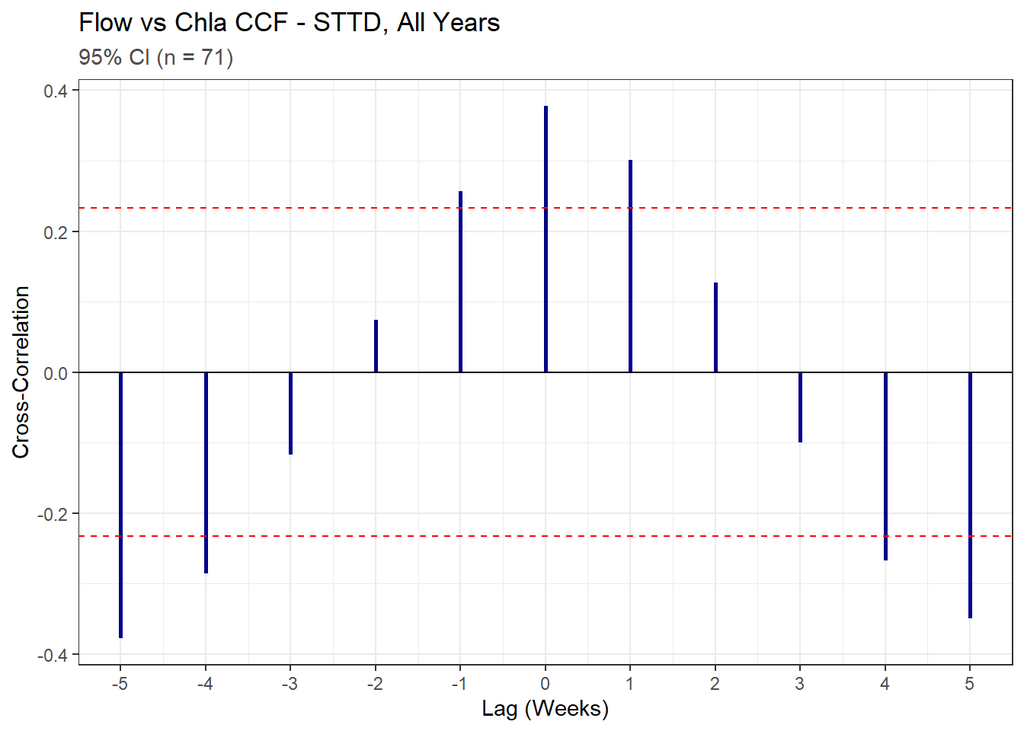

```r
ls_ccf_plt_chla_allyrs$STTD
```

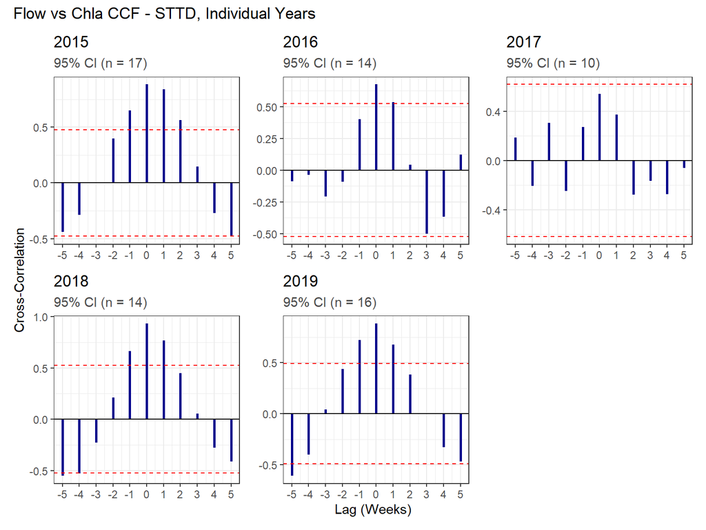

```r
ls_ccf_plt_chla_indiv_yrs$STTD
```

The chlorophyll plots show a consistent positive peak in the cross-correlation value at 0-lag, which indicates that a non-lagged LIS flow term for STTD is the best choice.

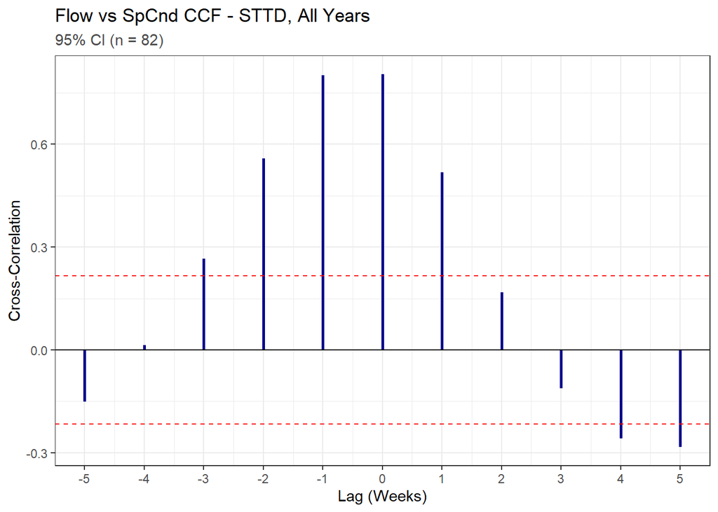

```r
ls_ccf_plt_spcnd_allyrs$STTD
```

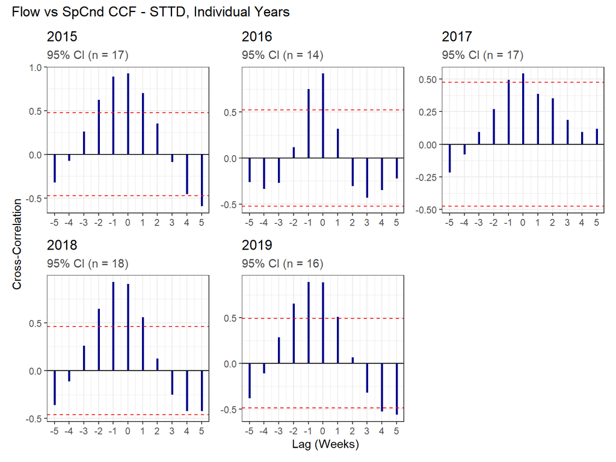

```r
ls_ccf_plt_spcnd_indiv_yrs$STTD
```

For specific conductance, the positive peak in the cross-correlation values are located at the -1 and 0 lag terms, which indicates that there is a slight lagged response of specific conductance values to increased LIS flow. This is probably because the lagged response is a few days, not a full week. With all of this information, I think we should use a non-lagged LIS flow term for STTD in the models. We’ll explore this further with some scatter plots of chlorophyll and flow comparing non-lagged flow with the lagged flow values.

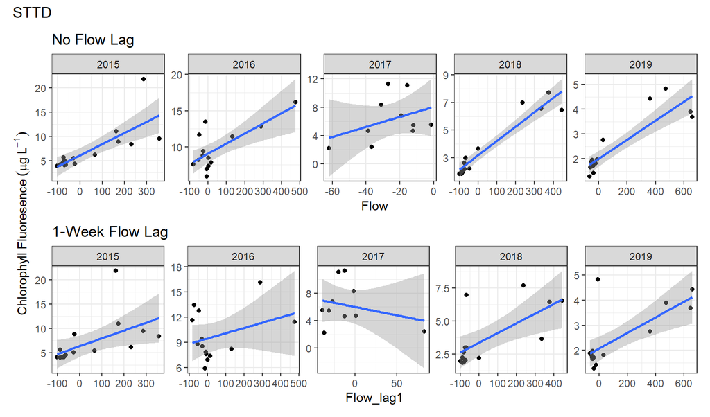

```r
plt_chla_flow_sttd <- ls_chla$STTD |>
  drop_na(Chla) |>
  plot_chla_flow(Flow, "No Flow Lag") +
  facet_wrap(vars(Year), nrow = 1, scales = "free")

plt_chla_flow_sttd_lag1 <- ls_chla$STTD |>
  mutate(Flow_lag1 = lag(Flow)) |>
  drop_na(Chla, Flow_lag1) |>
  plot_chla_flow(Flow_lag1, "1-Week Flow Lag") +
  facet_wrap(vars(Year), nrow = 1, scales = "free")

plt_chla_flow_sttd /
  plt_chla_flow_sttd_lag1 +
  plot_layout(axis_titles = "collect") +
  plot_annotation(title = "STTD")
```

The 1-week lag flow appears to have a weaker relationship with chlorophyll than non-lagged flow which confirms using the non-lagged LIS flow for the STTD model.

### LIB

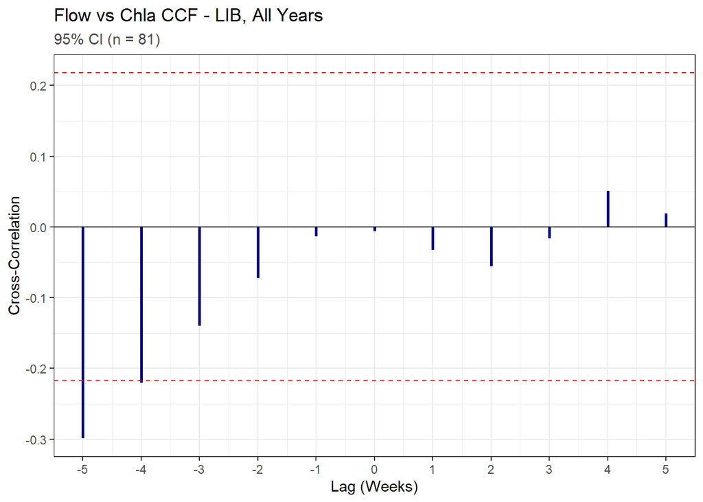

```r
ls_ccf_plt_chla_allyrs$LIB
```

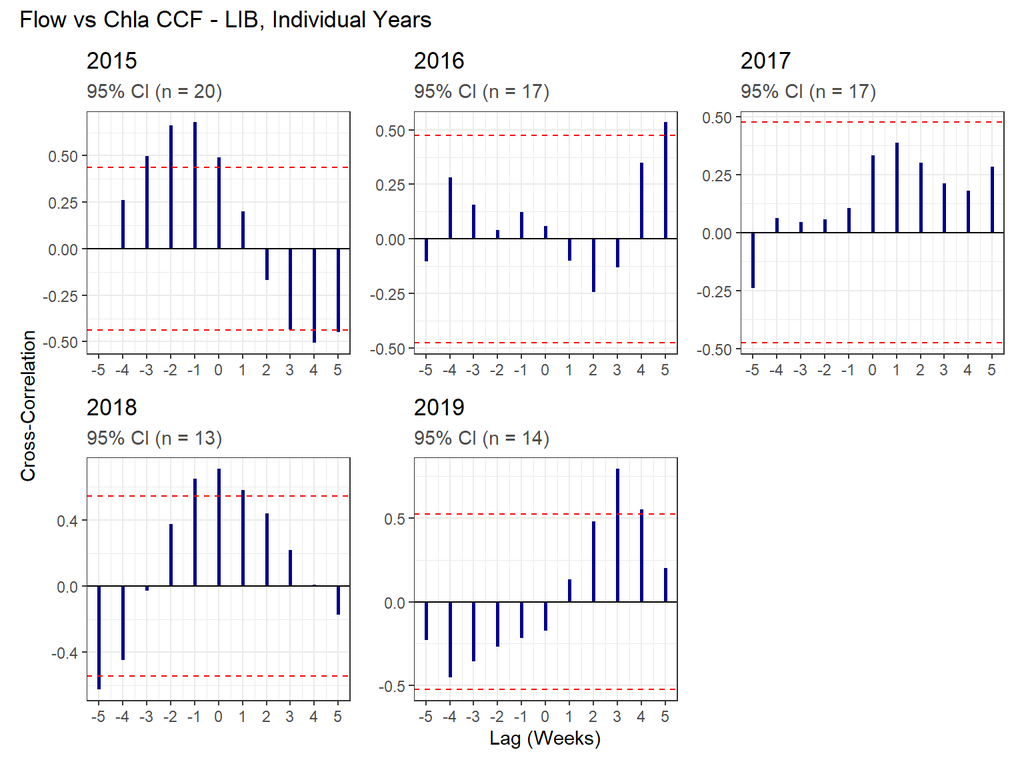

```r
ls_ccf_plt_chla_indiv_yrs$LIB
```

The chlorophyll plots are less clear and harder to interpret than those for STTD. It looks like there is a 1-2 week lag between increased flows at LIS and increased chlorophyll values at LIB in 2015; however, there seems to be a flushing effect (decreased chlorophyll values a few weeks after increased flows at LIS) in 2019, and a initial increase in chlorophyll values followed by a possible flushing effect 4 to 5 weeks later in 2018.

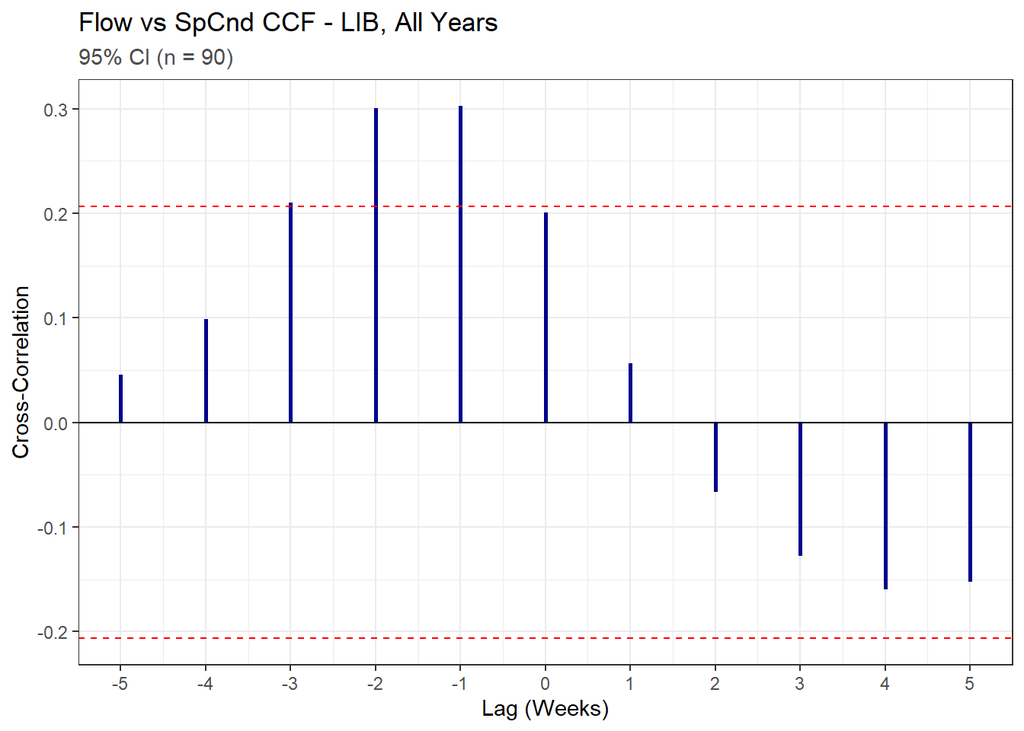

```r
ls_ccf_plt_spcnd_allyrs$LIB
```

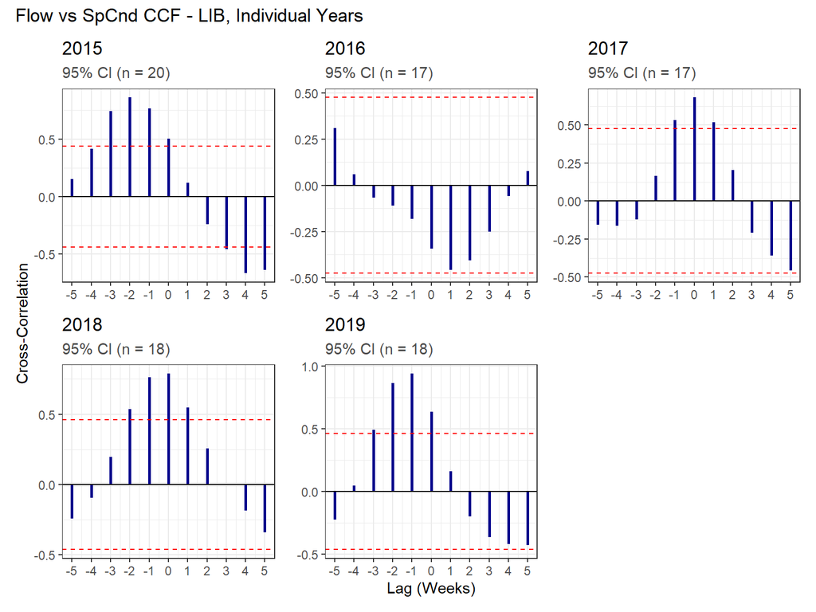

```r
ls_ccf_plt_spcnd_indiv_yrs$LIB
```

The specific conductance plots seem to be a little more clear. For all years, there is a 1-2 week lag between increased flows at LIS and increased specific conductance values at LIB. Looking at the individual years, the lag is between 0 and 2 weeks for most years.

### RVB

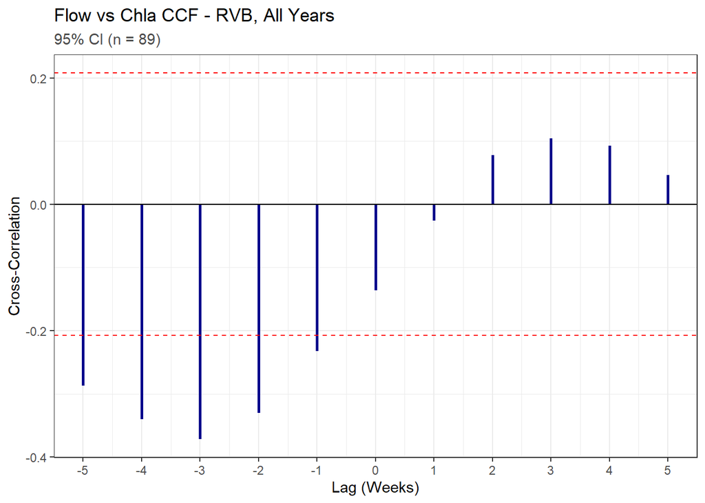

```r
ls_ccf_plt_chla_allyrs$RVB
```

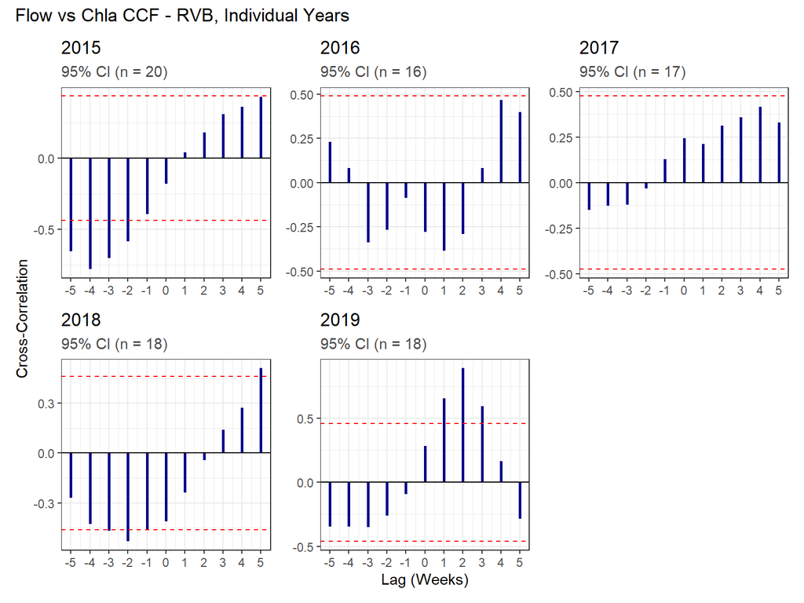

```r
ls_ccf_plt_chla_indiv_yrs$RVB
```

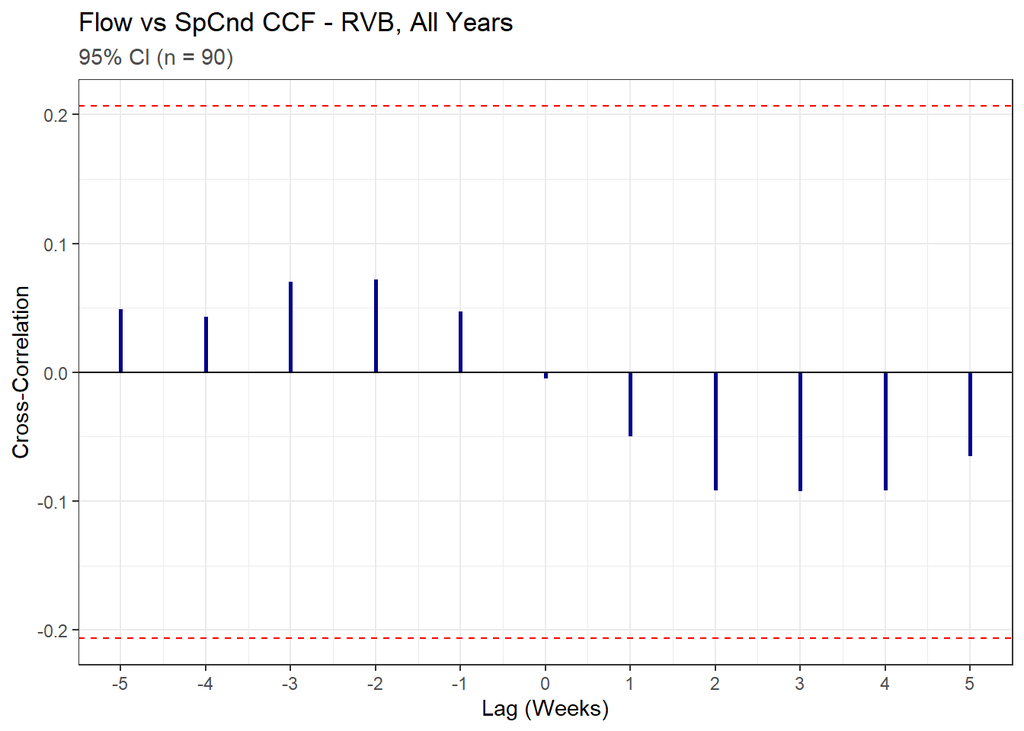

```r
ls_ccf_plt_spcnd_allyrs$RVB
```

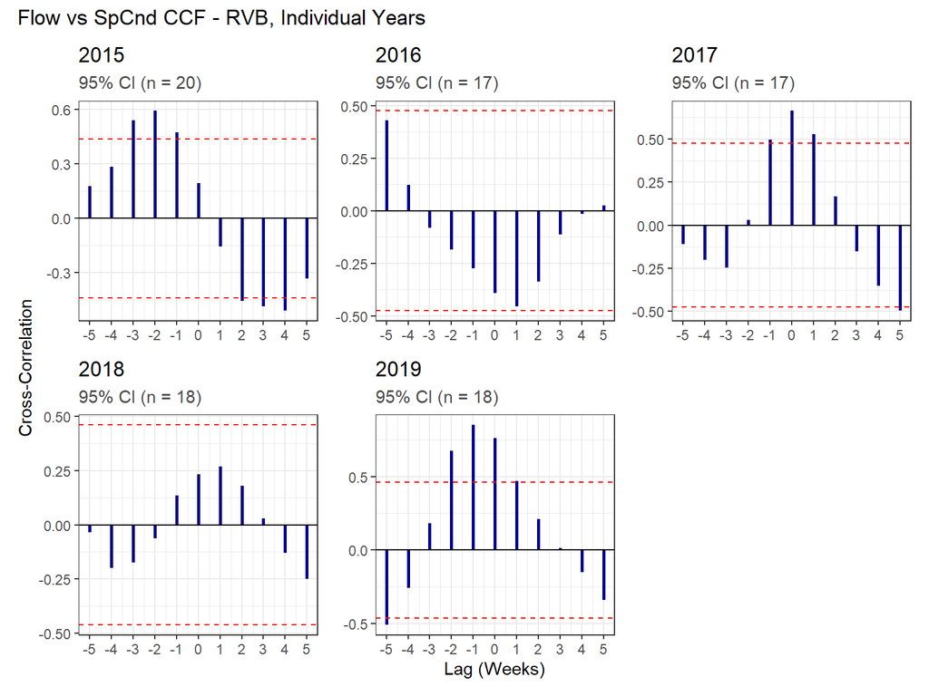

```r
ls_ccf_plt_spcnd_indiv_yrs$RVB
```

In summary, I think we should use an non-lagged LIS flow term for STTD, a two-week flow lag for LIB, and a 3-week flow lag for RVB. For LIB and RVB these lag values are consistent with the hydrodynamic modeling.

```r
# Add lagged flow values for LIB and RVB
ls_chla_flow_lag <- ls_chla |>
  map(\(x) group_by(x, Year)) |>
  map_at("LIB", \(x) mutate(x, Flow_lag2 = lag(Flow, n = 2))) |>
  map_at("RVB", \(x) mutate(x, Flow_lag3 = lag(Flow, n = 3))) |>
  map(\(x) ungroup(x))
```

## Flow vs Chlorophyll Scatterplots

Let’s explore the data with some plots. We’ll plot the data in scatter plots of chlorophyll and flow for each Station, using the lagged flow values for LIB and RVB.

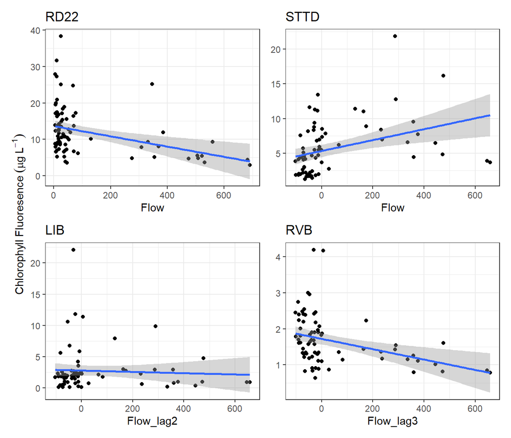

```r
ls_chla_flow_plt <- ls_chla_flow_lag |>
  imap(
    \(x, idx) {
      if (idx %in% c("RD22", "STTD")) {
        plot_chla_flow(x, Flow, idx)
      } else if (idx == "LIB") {
        plot_chla_flow(x, Flow_lag2, idx)
      } else if (idx == "RVB") {
        plot_chla_flow(x, Flow_lag3, idx)
      }
    }
  )

wrap_plots(ls_chla_flow_plt, ncol = 2, axis_titles = "collect_y")
```

Let’s break these scatterplots apart by year to see how these patterns vary annually.

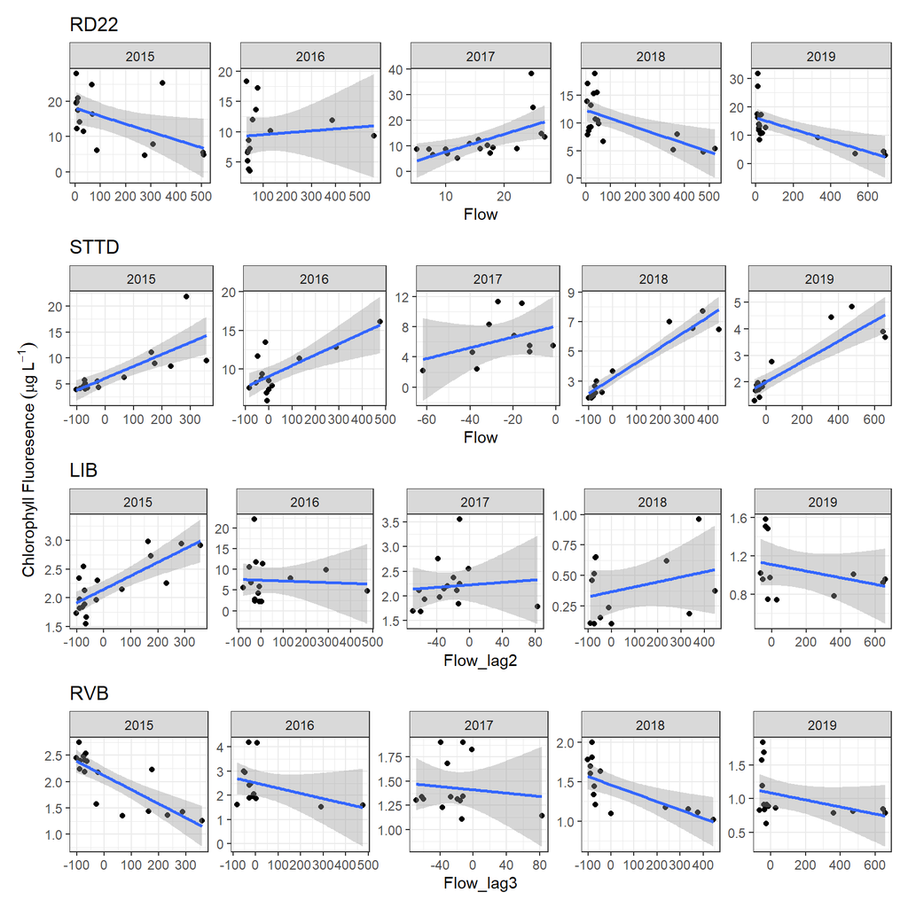

```r
ls_chla_flow_yr_plt <- ls_chla_flow_plt |>
  map(\(x) x + facet_wrap(vars(Year), nrow = 1, scales = "free"))

wrap_plots(ls_chla_flow_yr_plt, ncol = 1, axis_titles = "collect_y")
```

# Models

We will attempt to fit generalized additive models (GAM’s) to each station’s data set to help account for seasonality in the data. We’ll try running each GAM using a two-way interaction between Year and Weekly Average Flow, and a cyclic penalized cubic regression spline smooth term for week number to account for seasonality (restricting the k-value to 5 to reduce overfitting). Initially, we’ll run the GAM’s without accounting for serial autocorrelation.

## RD22

### Initial Model

```r
df_chla_rd22 <- ls_chla_flow_lag$RD22 |> drop_na(Flow, Chla_log)

m_gam_rd22 <- gam(
  Chla_log ~ Year_fct * Flow + s(Week, bs = "cc", k = 5),
  data = df_chla_rd22,
  method = "REML",
  knots = list(Week = c(0, 52))
)
```

Lets look at the model summary and diagnostics:

```r
check_gam_diagnostics(m_gam_rd22)
```

```
## ==================================================
##           GAM MODEL DIAGNOSTICS
## ==================================================
##
## --- 1. MODEL SUMMARY ---
##
## Family: gaussian
## Link function: identity
##
## Formula:
## Chla_log ~ Year_fct * Flow + s(Week, bs = "cc", k = 5)
##
## Parametric coefficients:
##                     Estimate Std. Error t value Pr(>|t|)
## (Intercept)        9.7354276  0.1157428  84.113  < 2e-16 ***
## Year_fct2016      -0.8259986  0.1708360  -4.835 7.51e-06 ***
## Year_fct2017      -0.9533764  0.2637595  -3.615  0.00056 ***
## Year_fct2018      -0.4106405  0.1514147  -2.712  0.00839 **
## Year_fct2019      -0.1324495  0.1488443  -0.890  0.37656
## Flow              -0.0016110  0.0005249  -3.069  0.00304 **
## Year_fct2016:Flow  0.0018560  0.0008289   2.239  0.02829 *
## Year_fct2017:Flow  0.0325829  0.0141204   2.308  0.02396 *
## Year_fct2018:Flow  0.0005245  0.0006934   0.756  0.45192
## Year_fct2019:Flow -0.0001885  0.0006129  -0.308  0.75930
## ---
## Signif. codes:  0 '***' 0.001 '**' 0.01 '*' 0.05 '.' 0.1 ' ' 1
##
## Approximate significance of smooth terms:
##         edf Ref.df     F  p-value
## s(Week) 2.3      3 7.789 3.41e-05 ***
## ---
## Signif. codes:  0 '***' 0.001 '**' 0.01 '*' 0.05 '.' 0.1 ' ' 1
##
## R-sq.(adj) =  0.581   Deviance explained = 63.8%
## -REML = 67.339  Scale est. = 0.12296   n = 83
##
## --- 2. BASIS DIMENSION CHECK (k.check) ---
##         k'      edf   k-index p-value
## s(Week)  3 2.300173 0.9255603    0.21
##
## *Note: If p-value is low, the basis dimension 'k' might be too small.*
##
## --- 3. NORMALITY TEST OF RESIDUALS ---
##
##  Shapiro-Wilk normality test
##
## data:  resids
## W = 0.98104, p-value = 0.2594
##
## Result: Fail to reject H0. Residuals appear normally distributed (p >= 0.05).
##
## --- 4. GENERATING APPRAISE PLOTS ---
## Displaying: Residual QQ-plot, Residuals vs Linear Predictor, Histogram, and Observed vs Fitted.
```

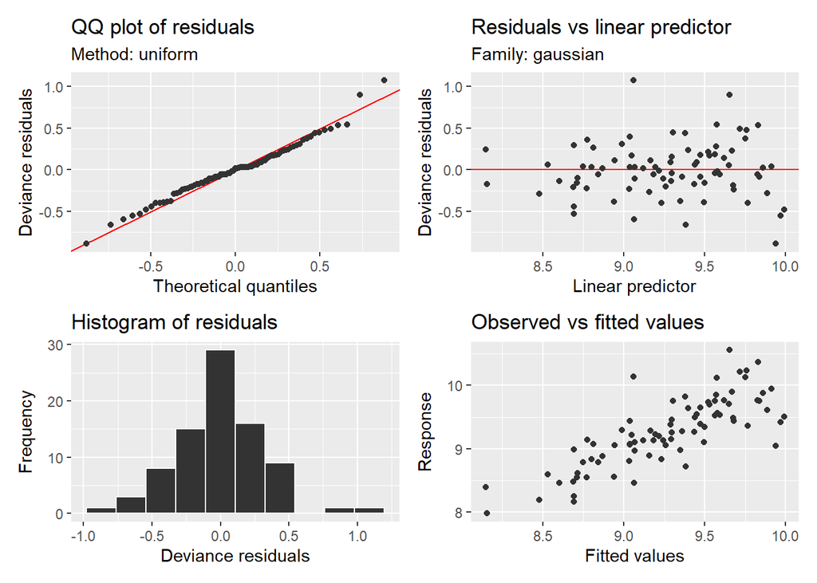

```
## --- 5. GENERATING SMOOTH TERM PLOTS ---
```

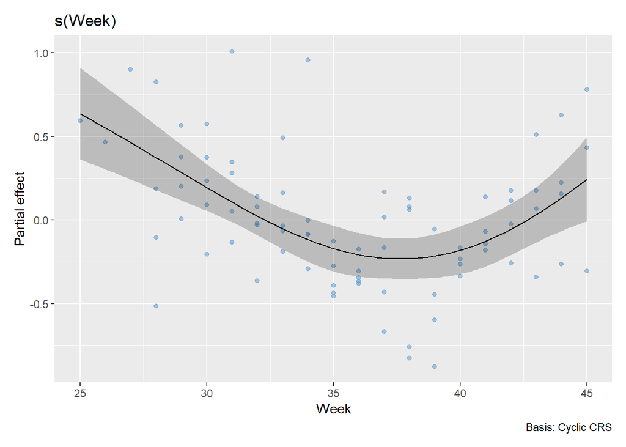

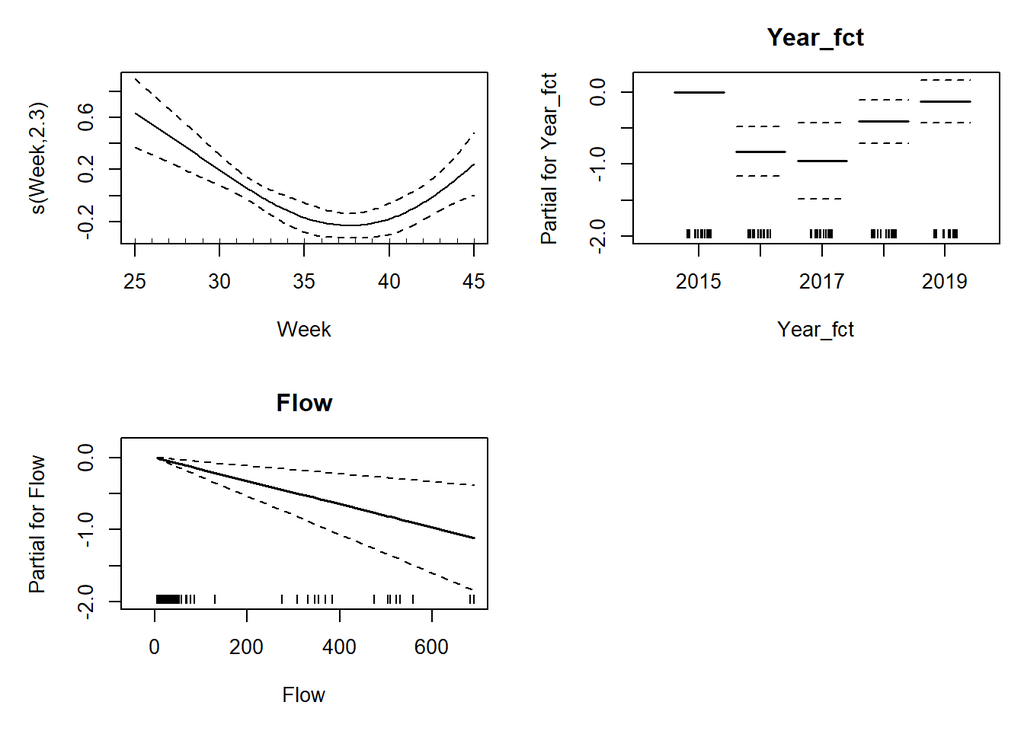

```r
check_gam_autocorr(m_gam_rd22)
```

```
## ==================================================
##        GAM RESIDUAL AUTOCORRELATION CHECK
## ==================================================
##
## --- 1. LJUNG-BOX TEST FOR SERIAL CORRELATION ---
##
##  Box-Ljung test
##
## data:  resids
## X-squared = 27.174, df = 20, p-value = 0.1304
##
## Result: Fail to reject H0. No significant residual autocorrelation (p >= 0.05).
##
## --- 2. PLOTTING AUTOCORRELATION FUNCTION (ACF) ---
```

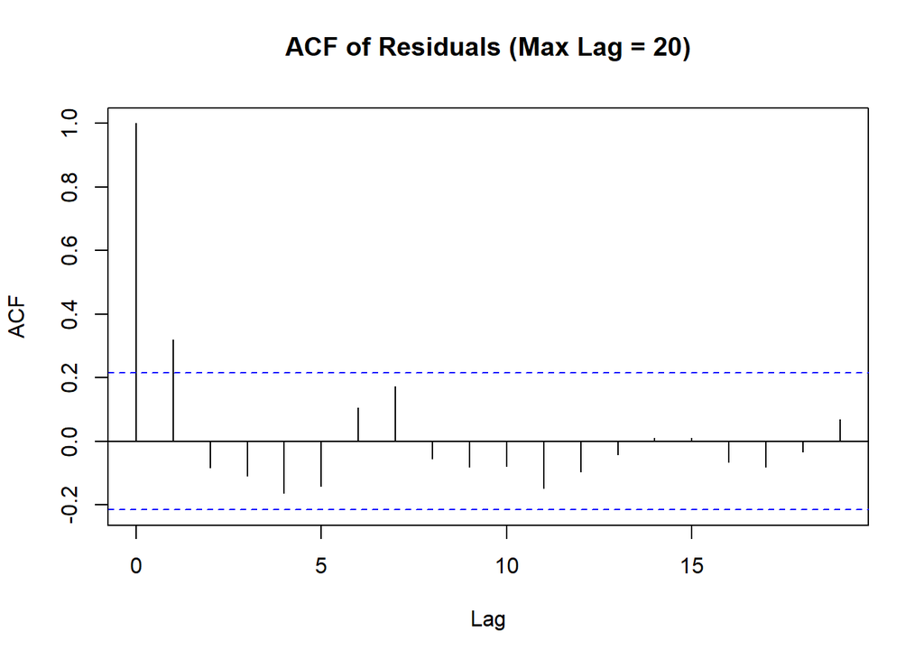

The diagnostic plots and stats look good. However, the residuals are autocorrelated.

### Model with lag terms

Now, we’ll try to deal with the residual autocorrelation. We’ll run a series of models adding 1 and 2 lag terms and compare how well they correct for autocorrelation.

```r
m_gam_rd22_lag1 <- gam(
  Chla_log ~ Year_fct * Flow + s(Week, bs = "cc", k = 5) + lag1,
  data = df_chla_rd22,
  method = "REML",
  knots = list(Week = c(0, 52))
)

check_gam_autocorr(m_gam_rd22_lag1)
```

```
## ==================================================
##        GAM RESIDUAL AUTOCORRELATION CHECK
## ==================================================
##
## --- 1. LJUNG-BOX TEST FOR SERIAL CORRELATION ---
##
##  Box-Ljung test
##
## data:  resids
## X-squared = 21.281, df = 20, p-value = 0.3808
##
## Result: Fail to reject H0. No significant residual autocorrelation (p >= 0.05).
##
## --- 2. PLOTTING AUTOCORRELATION FUNCTION (ACF) ---
```

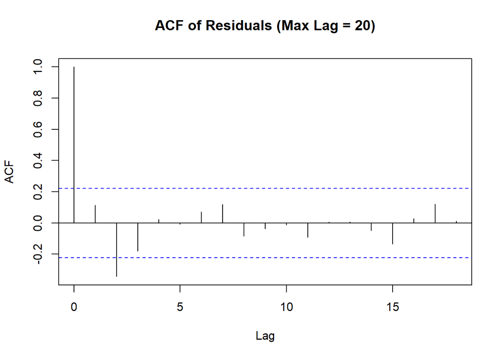

```r
m_gam_rd22_lag2 <- gam(
  Chla_log ~ Year_fct * Flow + s(Week, bs = "cc", k = 5) + lag1 + lag2,
  data = df_chla_rd22,
  method = "REML",
  knots = list(Week = c(0, 52))
)

check_gam_autocorr(m_gam_rd22_lag2)
```

```
## ==================================================
##        GAM RESIDUAL AUTOCORRELATION CHECK
## ==================================================
##
## --- 1. LJUNG-BOX TEST FOR SERIAL CORRELATION ---
##
##  Box-Ljung test
##
## data:  resids
## X-squared = 20.191, df = 20, p-value = 0.4461
##
## Result: Fail to reject H0. No significant residual autocorrelation (p >= 0.05).
##
## --- 2. PLOTTING AUTOCORRELATION FUNCTION (ACF) ---
```

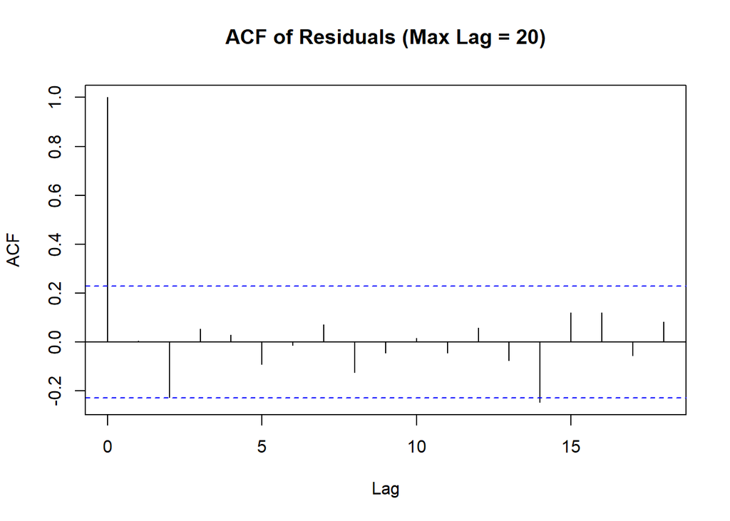

The model with 2 lag terms seems to be okay with autocorrelation according to the acf plot. Let’s take a closer look at that one.

```r
check_gam_diagnostics(m_gam_rd22_lag2)
```

```
## ==================================================
##           GAM MODEL DIAGNOSTICS
## ==================================================
##
## --- 1. MODEL SUMMARY ---
##
## Family: gaussian
## Link function: identity
##
## Formula:
## Chla_log ~ Year_fct * Flow + s(Week, bs = "cc", k = 5) + lag1 +
##     lag2
##
## Parametric coefficients:
##                     Estimate Std. Error t value Pr(>|t|)
## (Intercept)        7.5399987  1.1482450   6.567 1.48e-08 ***
## Year_fct2016      -0.5894910  0.1923485  -3.065  0.00329 **
## Year_fct2017      -0.7554201  0.2681538  -2.817  0.00659 **
## Year_fct2018      -0.3341099  0.1518633  -2.200  0.03174 *
## Year_fct2019      -0.0696332  0.1447652  -0.481  0.63230
## Flow              -0.0009265  0.0005115  -1.811  0.07519 .
## lag1               0.4566559  0.1321649   3.455  0.00103 **
## lag2              -0.2389602  0.1122388  -2.129  0.03745 *
## Year_fct2016:Flow  0.0007857  0.0007934   0.990  0.32605
## Year_fct2017:Flow  0.0311749  0.0155476   2.005  0.04956 *
## Year_fct2018:Flow  0.0004431  0.0006337   0.699  0.48714
## Year_fct2019:Flow -0.0001853  0.0005710  -0.325  0.74665
## ---
## Signif. codes:  0 '***' 0.001 '**' 0.01 '*' 0.05 '.' 0.1 ' ' 1
##
## Approximate significance of smooth terms:
##           edf Ref.df     F p-value
## s(Week) 2.172      3 5.151   8e-04 ***
## ---
## Signif. codes:  0 '***' 0.001 '**' 0.01 '*' 0.05 '.' 0.1 ' ' 1
##
## R-sq.(adj) =  0.694   Deviance explained =   75%
## -REML = 56.205  Scale est. = 0.094491  n = 73
##
## --- 2. BASIS DIMENSION CHECK (k.check) ---
##         k'     edf   k-index p-value
## s(Week)  3 2.17159 0.8836857   0.175
##
## *Note: If p-value is low, the basis dimension 'k' might be too small.*
##
## --- 3. NORMALITY TEST OF RESIDUALS ---
##
##  Shapiro-Wilk normality test
##
## data:  resids
## W = 0.98307, p-value = 0.4349
##
## Result: Fail to reject H0. Residuals appear normally distributed (p >= 0.05).
##
## --- 4. GENERATING APPRAISE PLOTS ---
## Displaying: Residual QQ-plot, Residuals vs Linear Predictor, Histogram, and Observed vs Fitted.
```

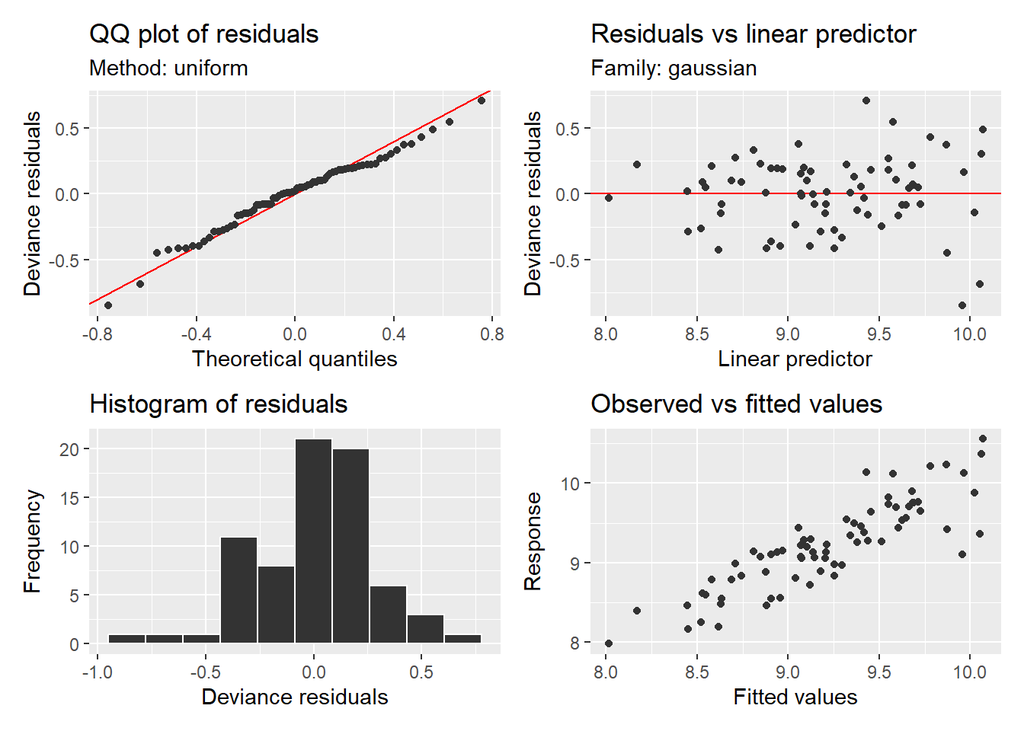

```
## --- 5. GENERATING SMOOTH TERM PLOTS ---
```

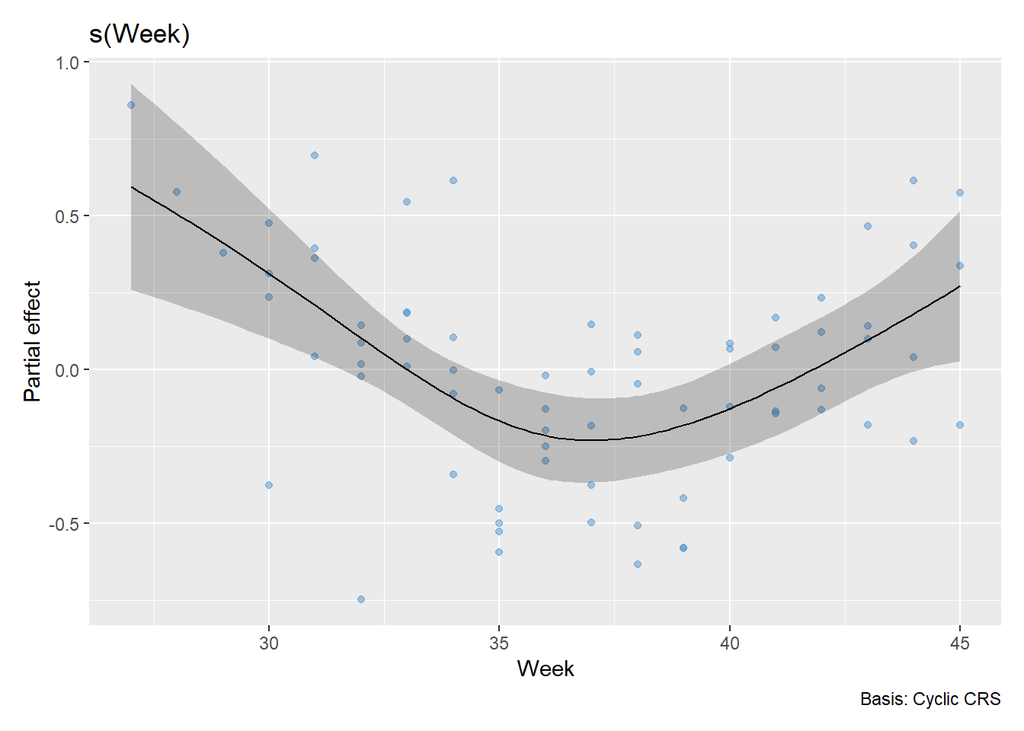

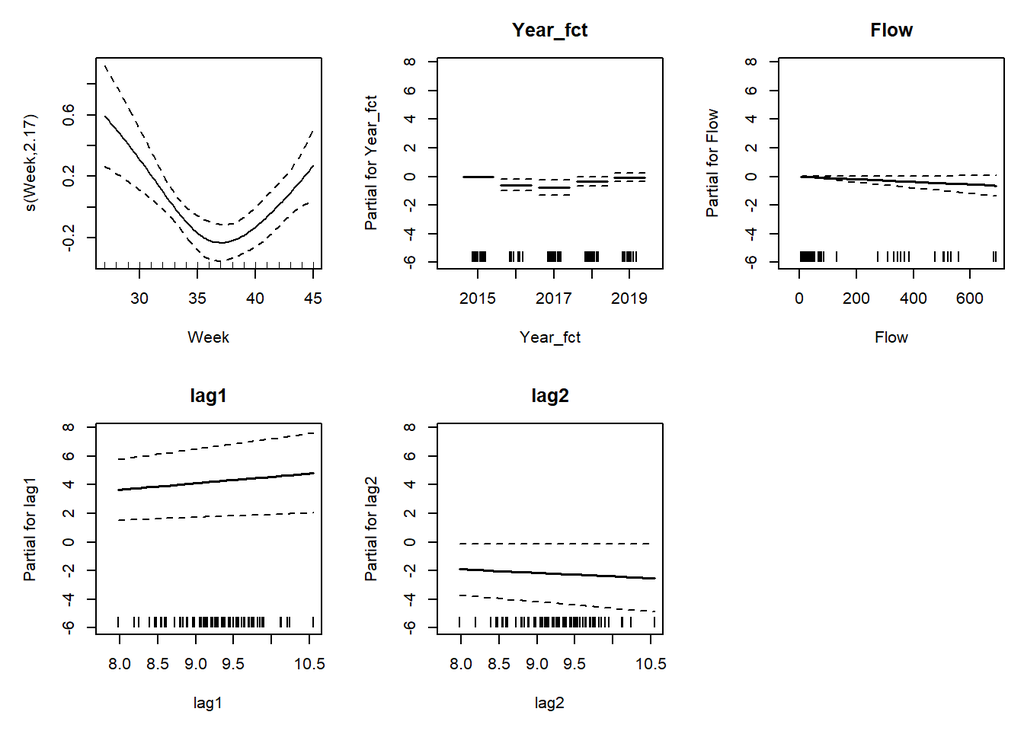

```r
anova(m_gam_rd22_lag2)
```

```
##
## Family: gaussian
## Link function: identity
##
## Formula:
## Chla_log ~ Year_fct * Flow + s(Week, bs = "cc", k = 5) + lag1 +
##     lag2
##
## Parametric Terms:
##               df      F p-value
## Year_fct       4  4.118 0.00522
## Flow           1  3.281 0.07519
## lag1           1 11.938 0.00103
## lag2           1  4.533 0.03745
## Year_fct:Flow  4  1.513 0.20997
##
## Approximate significance of smooth terms:
##           edf Ref.df     F p-value
## s(Week) 2.172  3.000 5.151   8e-04
```

The model diagnostics look really good. Before we proceed with this model for RD22, let’s take a closer look at how the back-transformed fitted values from the model match the observed values.

### Observed vs Fitted Values

```r
df_chla_rd22_lag <- df_chla_rd22 |> drop_na(lag1, lag2)

# Sample sizes for each year
df_chla_rd22_lag |> count(Year_fct)
```

```
## # A tibble: 5 × 2
##   Year_fct     n
##   <fct>    <int>
## 1 2015        14
## 2 2016        12
## 3 2017        15
## 4 2018        16
## 5 2019        16
```

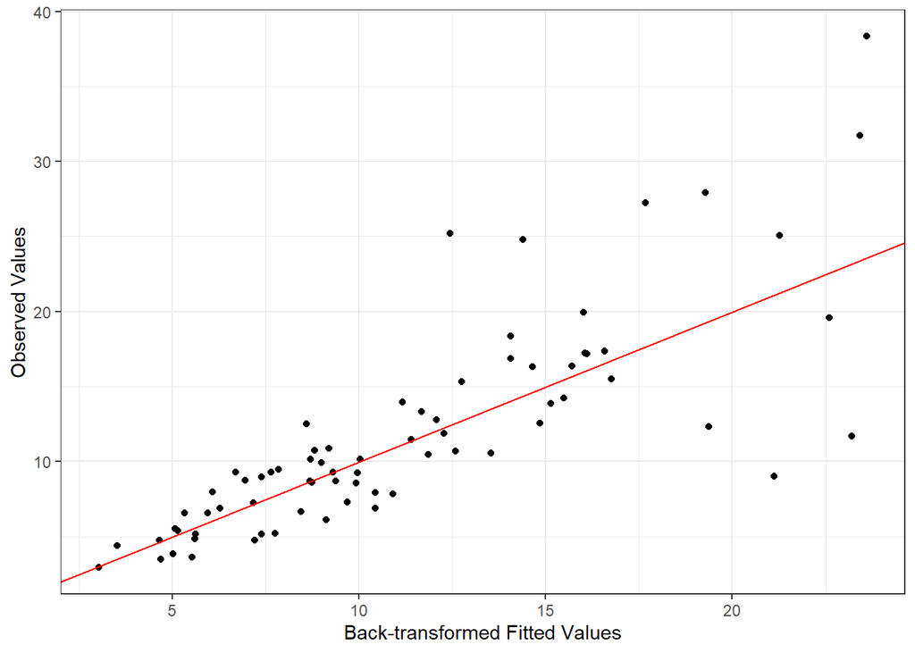

```r
plot_obs_vs_model_fit(m_gam_rd22_lag2, df_chla_rd22_lag)
```

The model fit looks pretty decent. Note that variability does increase as the chlorophyll values increase. Now, let’s look more closely at its results.

### Model Results

#### Effect of Flow by Year

Partial effect of flow on chlorophyll:

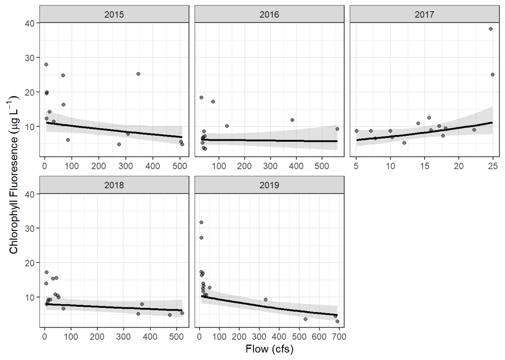

```r
# Calculate effects of flow on chlorophyll holding the non-focal variables constant -
# marginal effects/adjusted predictions
df_rd22_flow_eff <- calc_flow_yr_marg_eff(
  m_gam_rd22_lag2,
  df_chla_rd22_lag,
  "Flow"
)

# Create effects plot
plot_eff_flow_by_yr(df_rd22_flow_eff, df_chla_rd22_lag, "Flow")
```

#### Year Contrasts

```r
# Estimated marginal means for year
em_rd22_yr <- emmeans(m_gam_rd22_lag2, ~Year_fct)

# Tukey post-hoc contrasts
pairs(em_rd22_yr)
```

```
##  contrast                    estimate    SE   df t.ratio p.value
##  Year_fct2015 - Year_fct2016   0.4981 0.156 58.8   3.201  0.0181
##  Year_fct2015 - Year_fct2017  -2.8695 1.590 58.8  -1.809  0.3781
##  Year_fct2015 - Year_fct2018   0.2826 0.123 58.8   2.298  0.1602
##  Year_fct2015 - Year_fct2019   0.0912 0.118 58.8   0.773  0.9374
##  Year_fct2016 - Year_fct2017  -3.3676 1.580 58.8  -2.136  0.2188
##  Year_fct2016 - Year_fct2018  -0.2155 0.130 58.8  -1.652  0.4713
##  Year_fct2016 - Year_fct2019  -0.4069 0.138 58.8  -2.939  0.0365
##  Year_fct2017 - Year_fct2018   3.1521 1.590 58.8   1.984  0.2864
##  Year_fct2017 - Year_fct2019   2.9607 1.580 58.8   1.870  0.3444
##  Year_fct2018 - Year_fct2019  -0.1914 0.112 58.8  -1.707  0.4378
##
## P value adjustment: tukey method for comparing a family of 5 estimates
```

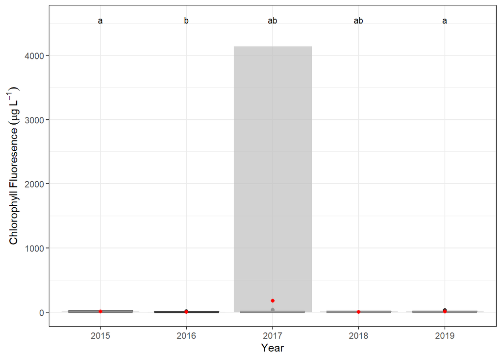

```r
# Create boxplot showing Tukey post-hoc results
boxplot_cont_yr(em_rd22_yr, df_chla_rd22_lag)
```

The model seems way off for 2017. This is most likely because emmeans is using a Flow value outside of the range of flow values that occurred during 2017. I think this model is good for looking at the effects of flow by year, but not for differences between years.

## STTD

### Initial Model

```r
df_chla_sttd <- ls_chla_flow_lag$STTD |> drop_na(Flow, Chla_log)

m_gam_sttd <- gam(
  Chla_log ~ Year_fct * Flow + s(Week, bs = "cc", k = 5),
  data = df_chla_sttd,
  method = "REML",
  knots = list(Week = c(0, 52))
)
```

Lets look at the model summary and diagnostics:

```r
check_gam_diagnostics(m_gam_sttd)
```

```
## ==================================================
##           GAM MODEL DIAGNOSTICS
## ==================================================
##
## --- 1. MODEL SUMMARY ---
##
## Family: gaussian
## Link function: identity
##
## Formula:
## Chla_log ~ Year_fct * Flow + s(Week, bs = "cc", k = 5)
##
## Parametric coefficients:
##                     Estimate Std. Error t value Pr(>|t|)
## (Intercept)        8.6132917  0.0666283 129.274  < 2e-16 ***
## Year_fct2016       0.4696569  0.1004782   4.674 1.68e-05 ***
## Year_fct2017       0.4404389  0.1706566   2.581  0.01228 *
## Year_fct2018      -0.6585791  0.0997395  -6.603 1.11e-08 ***
## Year_fct2019      -1.0636400  0.0985773 -10.790 8.98e-16 ***
## Flow               0.0027619  0.0004435   6.227 4.83e-08 ***
## Year_fct2016:Flow -0.0015045  0.0006544  -2.299  0.02495 *
## Year_fct2017:Flow  0.0145144  0.0051610   2.812  0.00661 **
## Year_fct2018:Flow -0.0002740  0.0005775  -0.474  0.63689
## Year_fct2019:Flow -0.0013625  0.0005152  -2.644  0.01039 *
## ---
## Signif. codes:  0 '***' 0.001 '**' 0.01 '*' 0.05 '.' 0.1 ' ' 1
##
## Approximate significance of smooth terms:
##               edf Ref.df F p-value
## s(Week) 8.792e-05      3 0   0.562
##
## R-sq.(adj) =  0.846   Deviance explained = 86.6%
## -REML = 43.239  Scale est. = 0.072301  n = 71
##
## --- 2. BASIS DIMENSION CHECK (k.check) ---
##         k'         edf   k-index p-value
## s(Week)  3 8.79212e-05 0.8037782  0.0475
##
## *Note: If p-value is low, the basis dimension 'k' might be too small.*
##
## --- 3. NORMALITY TEST OF RESIDUALS ---
##
##  Shapiro-Wilk normality test
##
## data:  resids
## W = 0.97594, p-value = 0.1896
##
## Result: Fail to reject H0. Residuals appear normally distributed (p >= 0.05).
##
## --- 4. GENERATING APPRAISE PLOTS ---
## Displaying: Residual QQ-plot, Residuals vs Linear Predictor, Histogram, and Observed vs Fitted.
```

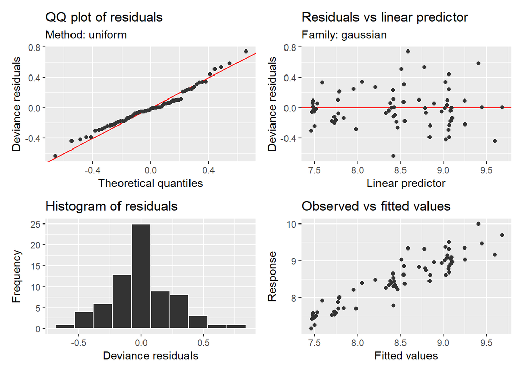

```
## --- 5. GENERATING SMOOTH TERM PLOTS ---
```

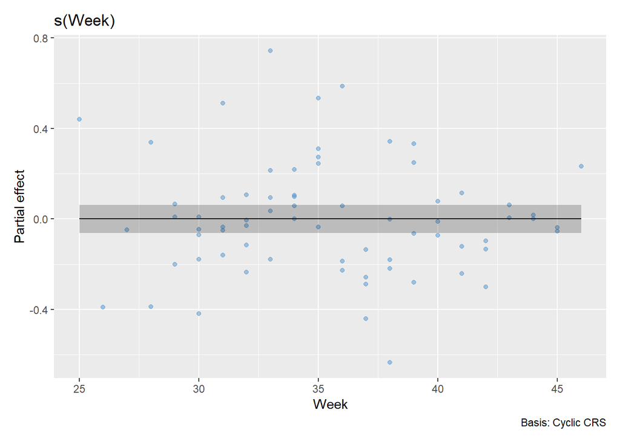

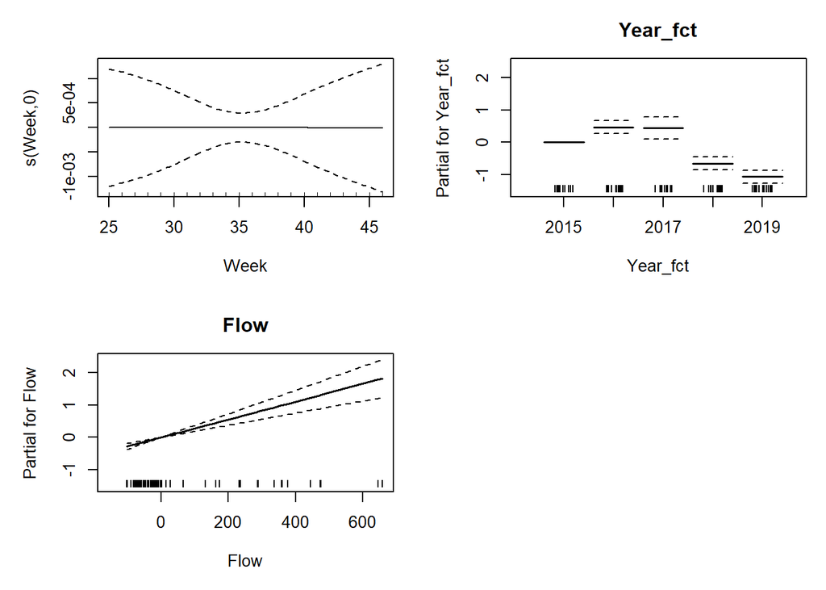

```r
check_gam_autocorr(m_gam_sttd)
```

```
## ==================================================
##        GAM RESIDUAL AUTOCORRELATION CHECK
## ==================================================
##
## --- 1. LJUNG-BOX TEST FOR SERIAL CORRELATION ---
##
##  Box-Ljung test
##
## data:  resids
## X-squared = 17.335, df = 20, p-value = 0.6311
##
## Result: Fail to reject H0. No significant residual autocorrelation (p >= 0.05).
##
## --- 2. PLOTTING AUTOCORRELATION FUNCTION (ACF) ---
```

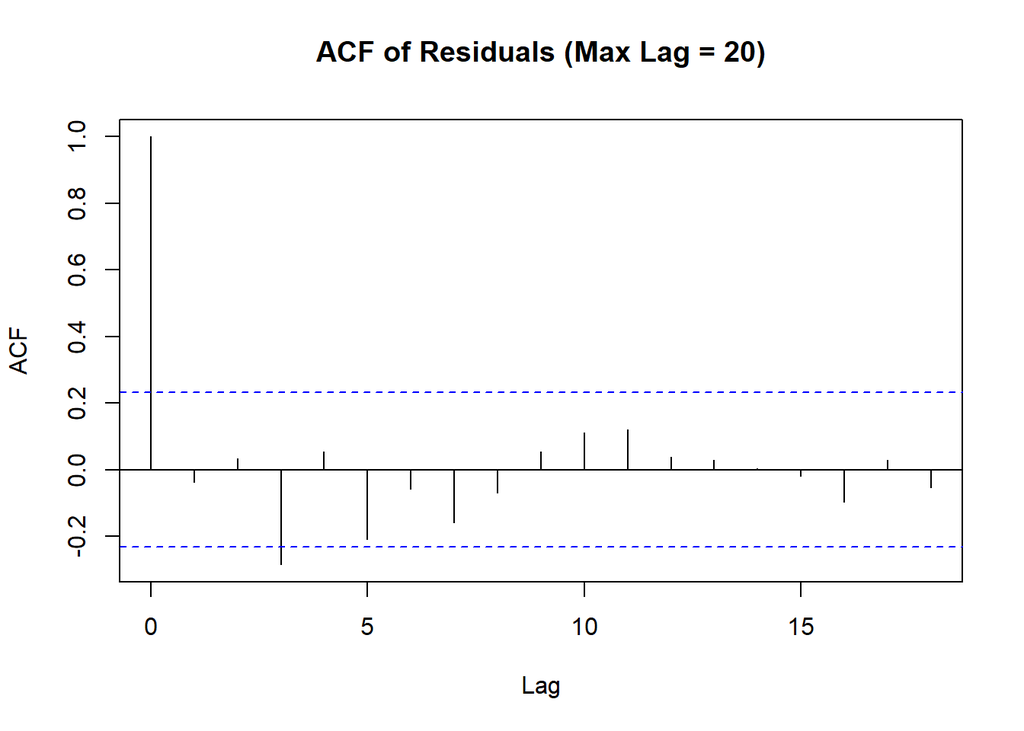

```r
anova(m_gam_sttd)
```

```
##
## Family: gaussian
## Link function: identity
##
## Formula:
## Chla_log ~ Year_fct * Flow + s(Week, bs = "cc", k = 5)
##
## Parametric Terms:
##               df      F  p-value
## Year_fct       4 70.083  < 2e-16
## Flow           1 38.779 4.83e-08
## Year_fct:Flow  4  5.163   0.0012
##
## Approximate significance of smooth terms:
##               edf    Ref.df F p-value
## s(Week) 8.792e-05 3.000e+00 0   0.562
```